# INLA Mortality 8.2

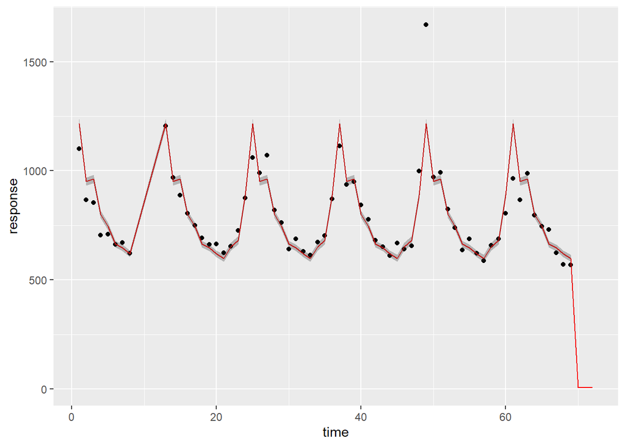

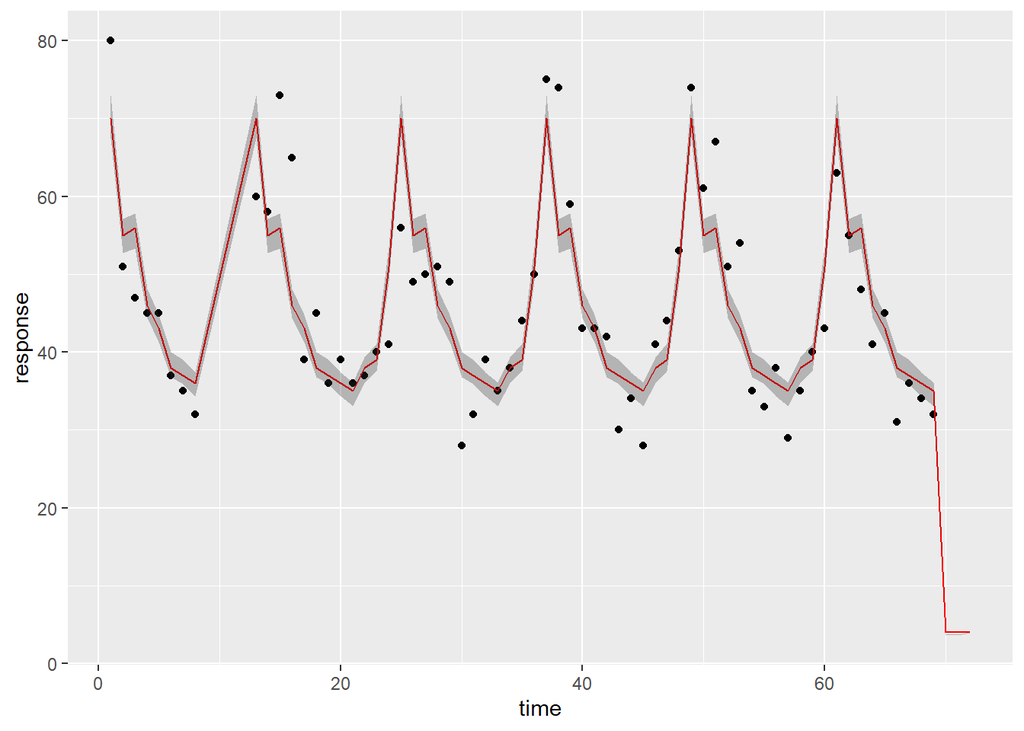

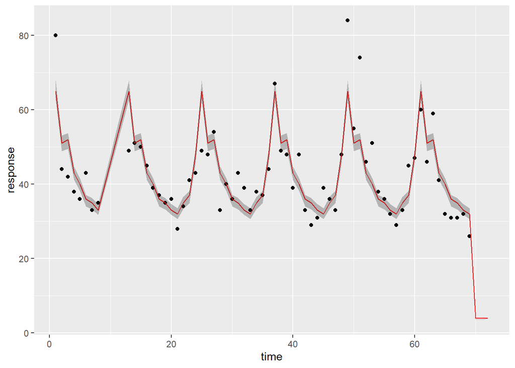

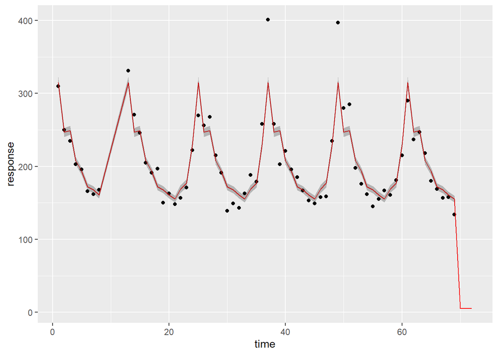

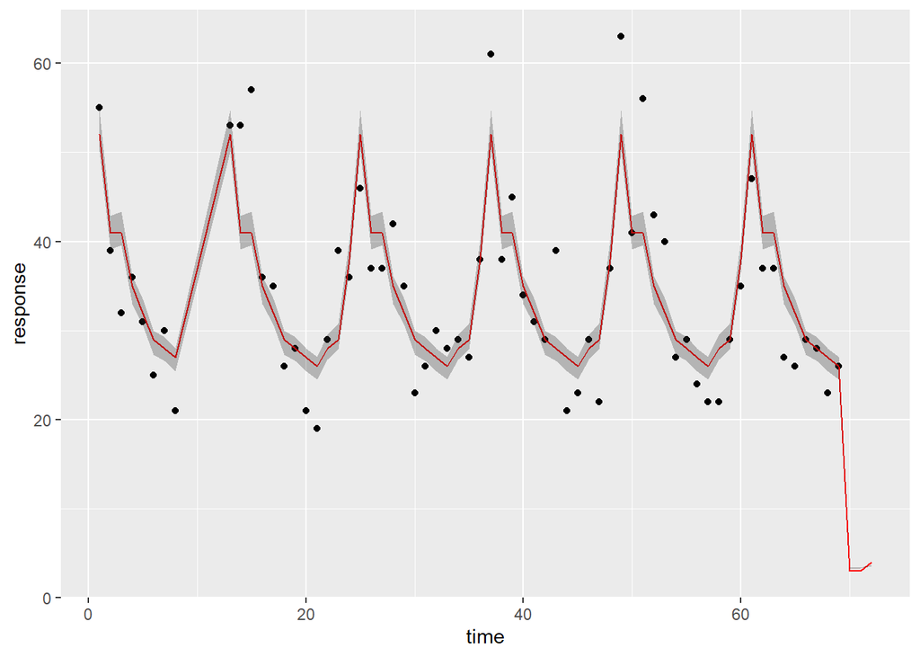

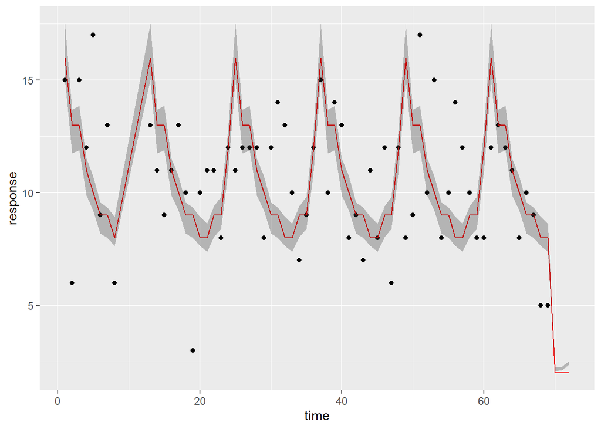

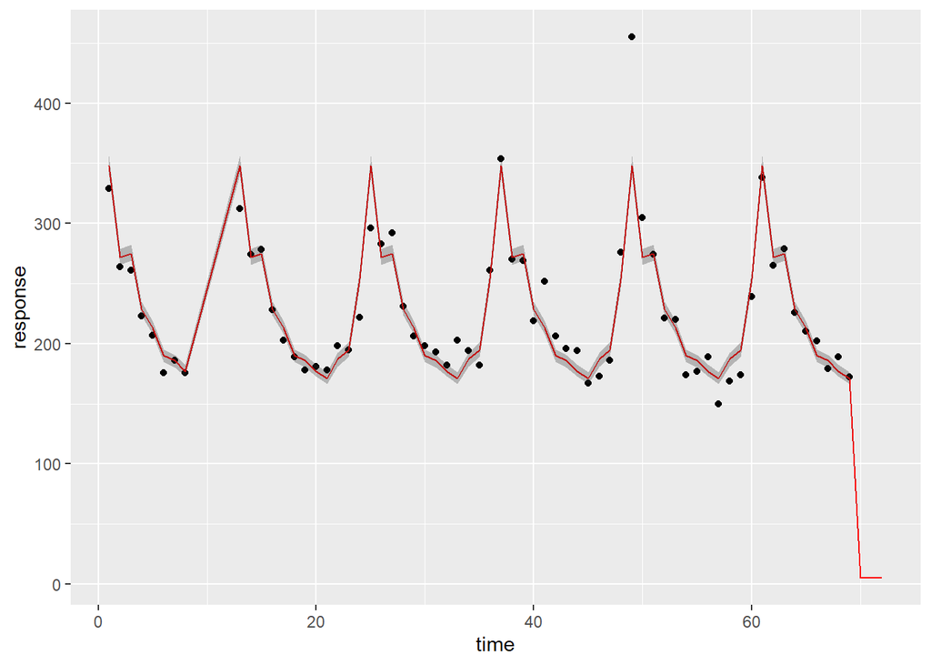

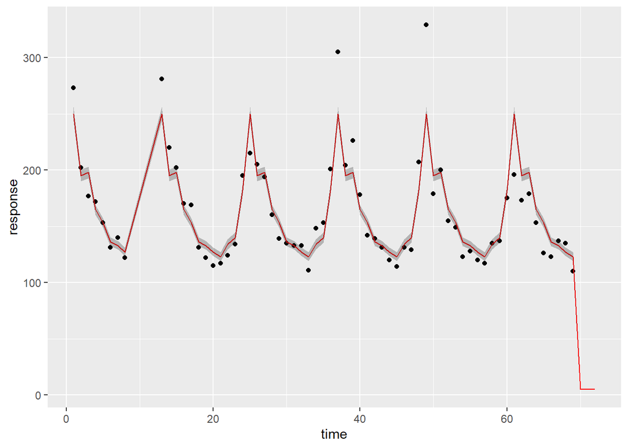

```r
#Plot of posterior predictive estimates with credible interval bands OVERLAID on response

for (i in 1:num_clus){
  df = inla_train_data %>% filter(id == i) %>% select(response)
  preds = preds_ref_model2 %>% filter(id == i)
  df = cbind(df,preds)

  post_pred_plot = df %>% ggplot(aes(x=time,y=response)) + geom_point() +
    geom_line(aes(y=mean),color = "red") + geom_ribbon(aes(ymin = `0.025quant`,ymax = `0.975quant`),alpha = 0.3)
  print(post_pred_plot)
}
```

```r
# #One call to ggplot (doesn't look as good)
# preds_ref_model2 %>% ggplot(aes(x=time,y=mean)) + geom_line() + geom_ribbon(aes(ymin = `0.025quant`,ymax = `0.975quant`),alpha = 0.3) + facet_wrap(~ id)

# #Combine plots with library patchwork
# pp_plot_ref_model2.1 = preds_ref_model2 %>% filter(id == 1) %>% ggplot(aes(x=time,y=mean)) + geom_line() + geom_ribbon(aes(ymin = `0.025quant`,ymax = `0.975quant`),alpha = 0.3)
#
# pp_plot_ref_model2.2 = preds_ref_model2 %>% filter(id == 2) %>% ggplot(aes(x=time,y=mean)) + geom_line() + geom_ribbon(aes(ymin = `0.025quant`,ymax = `0.975quant`),alpha = 0.3)
#
# pp_plot_ref_model2.3 = preds_ref_model2 %>% filter(id == 3) %>% ggplot(aes(x=time,y=mean)) + geom_line() + geom_ribbon(aes(ymin = `0.025quant`,ymax = `0.975quant`),alpha = 0.3)
#
# pp_plot_ref_model2.4 = preds_ref_model2 %>% filter(id == 4) %>% ggplot(aes(x=time,y=mean)) + geom_line() + geom_ribbon(aes(ymin = `0.025quant`,ymax = `0.975quant`),alpha = 0.3)
#
# pp_plot_ref_model2.5 = preds_ref_model2 %>% filter(id == 5) %>% ggplot(aes(x=time,y=mean)) + geom_line() + geom_ribbon(aes(ymin = `0.025quant`,ymax = `0.975quant`),alpha = 0.3)
#
# pp_plot_ref_model2.6 = preds_ref_model2 %>% filter(id == 6) %>% ggplot(aes(x=time,y=mean)) + geom_line() + geom_ribbon(aes(ymin = `0.025quant`,ymax = `0.975quant`),alpha = 0.3)
#
# pp_plot_ref_model2.7 = preds_ref_model2 %>% filter(id == 7) %>% ggplot(aes(x=time,y=mean)) + geom_line() + geom_ribbon(aes(ymin = `0.025quant`,ymax = `0.975quant`),alpha = 0.3)
#
# pp_plot_ref_model2.8 = preds_ref_model2 %>% filter(id == 8) %>% ggplot(aes(x=time,y=mean)) + geom_line() + geom_ribbon(aes(ymin = `0.025quant`,ymax = `0.975quant`),alpha = 0.3)
#
# pp_plot_ref_model2.1 + pp_plot_ref_model2.2 + pp_plot_ref_model2.3 + pp_plot_ref_model2.4 + pp_plot_ref_model2.5 + pp_plot_ref_model2.6 + pp_plot_ref_model2.7 + pp_plot_ref_model2.8
```

## Fitting a GP regression model

The third and final reference model we wanted to fit was a simple Gaussian Process regression. However, since our response is not continuous, we had to model the corresponding rates first, then convert it back into counts.

In other words, we used the rate of respiratory related mortality (per 100k people) for each cluster as our dependent variable for this model (see cluster_mortality_rate). Then after obtaining posterior predictive fitted values from our GP regression in INLA, I converted the estimated rates for each cluster back into counts by multiplying the rate value by the population of said cluster and dividing by 100,000 i.e.

$\frac{Y_i}{population_i} = \frac{\lambda_i}{100000} = f(t) + \epsilon_i$ for $i=1,...,8$ where $f(t) \sim GP(m(t),k(t,t'))$ and $t = 1,...,72$

In order for GP model estimation to be feasible in INLA, one has to solve the following SPDE: $(\kappa^2 - \Delta)^{\frac{\alpha}{2}} (\tau f(x) = W(x))$ where $\kappa$ is a scale parameter, $\Delta$ is the Laplacian, $\alpha$ is a smoothness parameter, $\tau$ relates to the variance of $f$, and $W(x)$ is a Gaussian white noise process of dimension $d$. The stationary solution $f$ turns out to have a Matern covariance of the form:

$Cov(f(0),f(x)) = \frac{\sigma^2}{2^{\nu-1} \Gamma(\nu)} (\kappa ||x||)^{\nu} K_{\nu}(\kappa ||x||)$ where $K_{\nu}$ is a Matern family kernel, $\nu = \alpha - d/2$, and the marginal variance $\sigma^2 = \frac{\Gamma(\nu)}{\Gamma(\alpha)(4\pi)^{d/2}\kappa^{2\nu}\tau^2}$

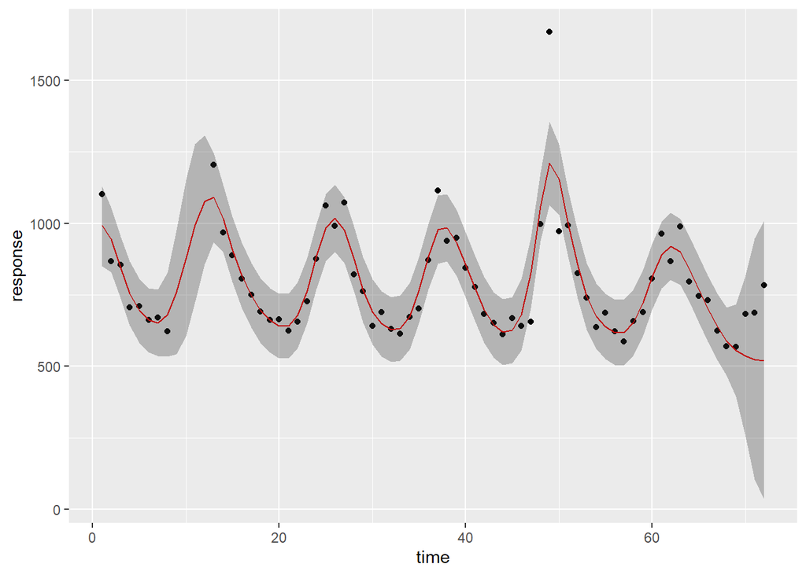

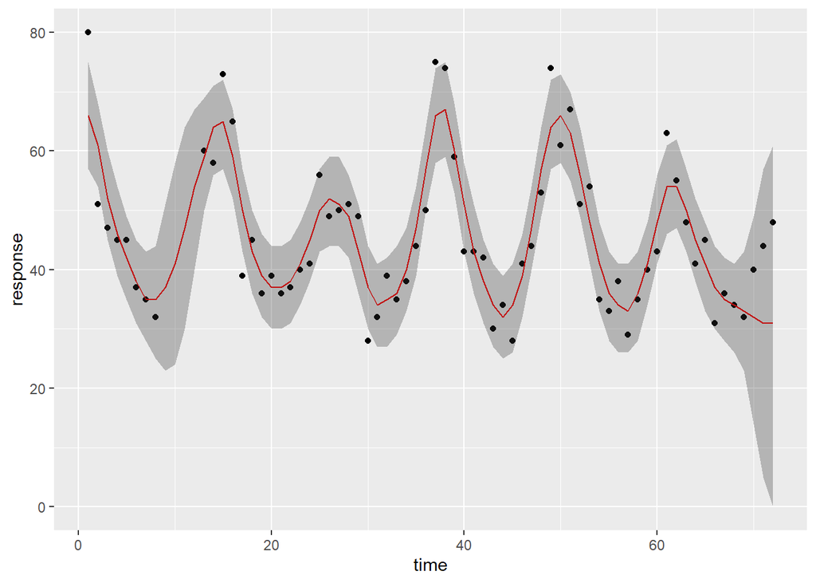

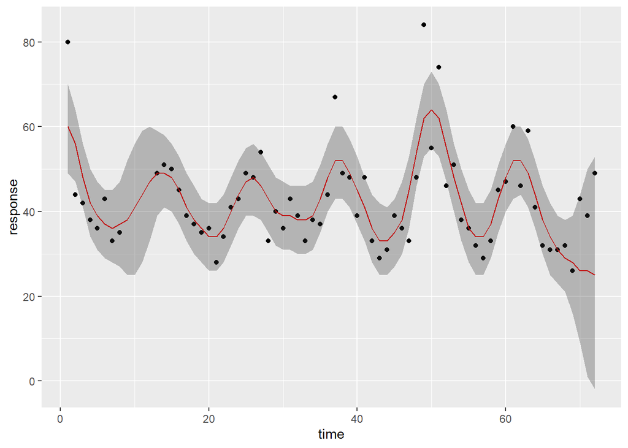

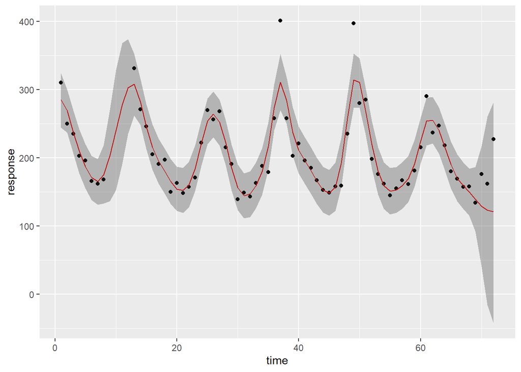

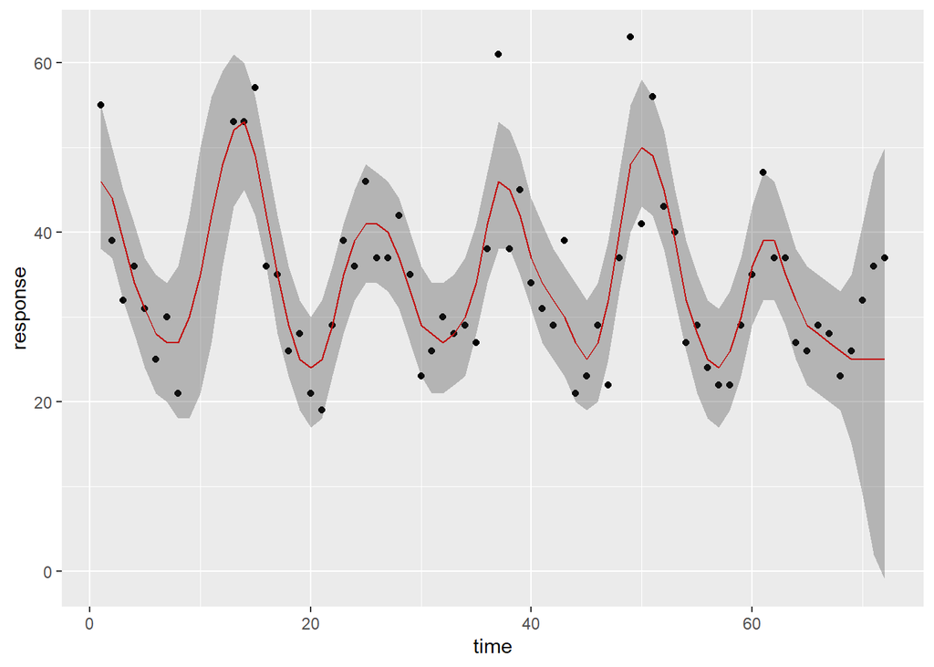

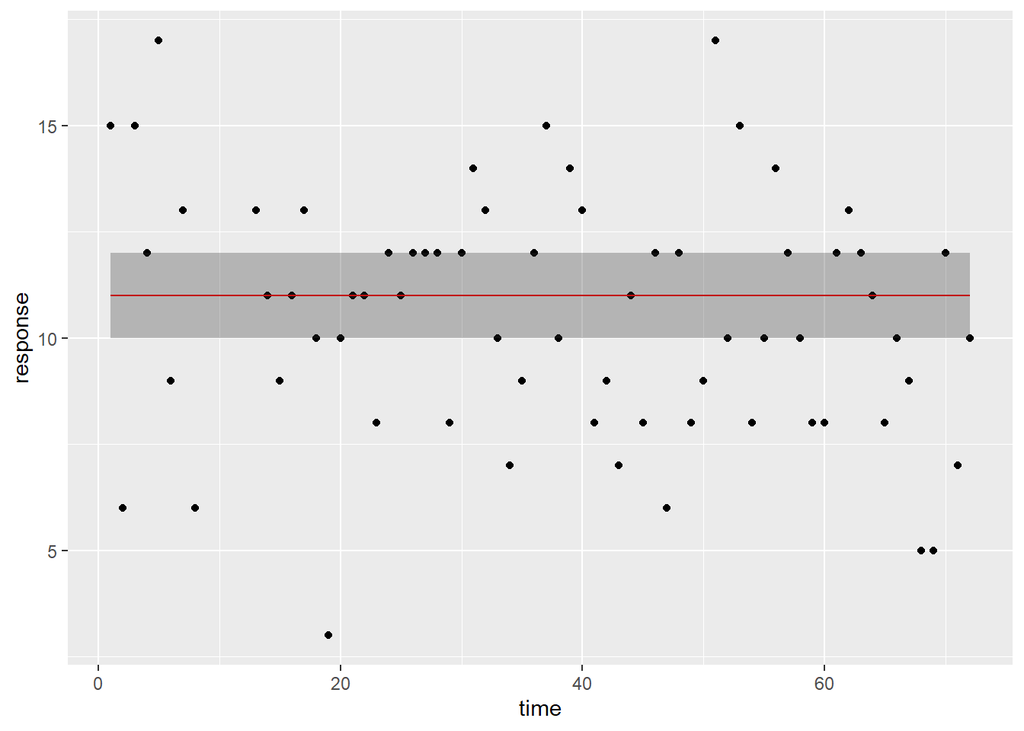

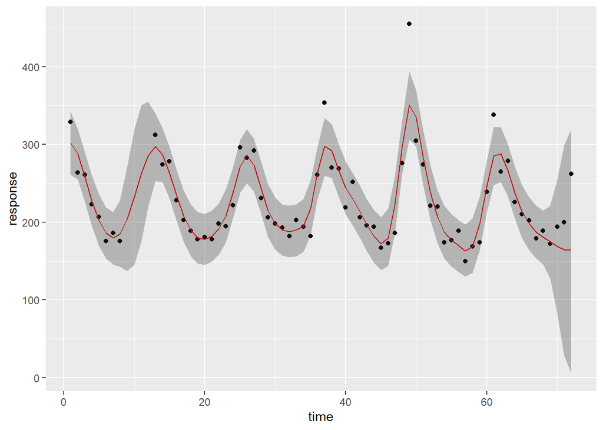

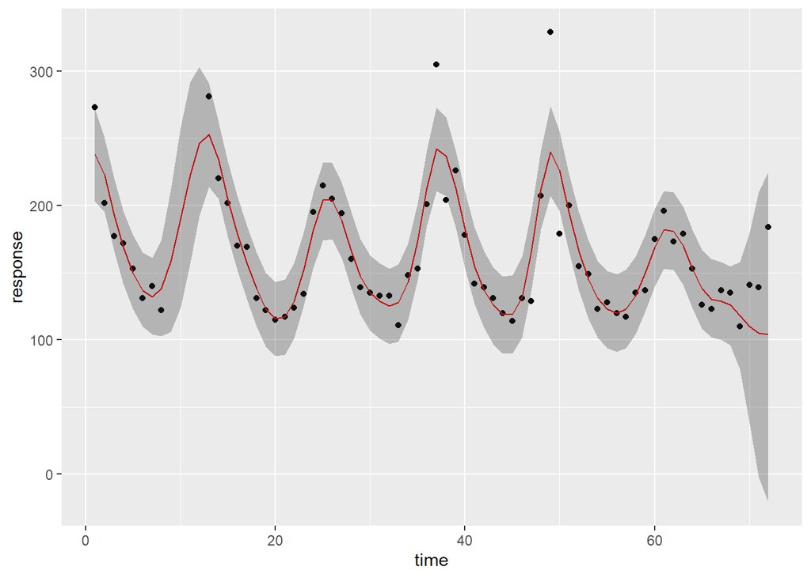

```r
num_clus = max(inla_gp_data$id)
cluster_rmse_gp = rep(0,num_clus)
test_rmse_gp = rep(0,num_clus)

for (i in 1:num_clus){
  clus_gp_data = inla_gp_data %>% filter(id == i)
  true_mortality = inla_test_data %>% filter(id == i)

  #Setting things up
  nbasis = 12
  mesh = inla.mesh.1d(seq(min(clus_gp_data$time),max(clus_gp_data$time)),length.out = nbasis,degree = 2)

  #Creating a SPDE object
  alpha <- 2
  nu <- alpha - 1/2
  sigma0 <- sd(na.omit(clus_gp_data$response))
  rho0 <- 0.25*(max(clus_gp_data$time) - min(clus_gp_data$time))
  kappa0 <- sqrt(8 * nu)/rho0
  tau0 <- 1 / (4 * kappa0^3 * sigma0^2)^0.5
  spde <- inla.spde2.matern(mesh, alpha=alpha,
                        B.tau = cbind(log(tau0), 1, 0),
                        B.kappa = cbind(log(kappa0), 0, 1),
                        theta.prior.prec = 1e-4)

  A = inla.spde.make.A(mesh,loc = clus_gp_data$time)

  #Even though 1-dimensional need to set an index
  index <- inla.spde.make.index("sinc", n.spde = spde$n.spde)

  st.est <- inla.stack(data=list(y=clus_gp_data$response), A=list(A),
                effects=list(index),  tag="est")

  #Fitting the model
  gp_formula <- y ~ -1 + f(sinc, model=spde)
  gp_data <- inla.stack.data(st.est)

  gpr_model <- inla(gp_formula, data=gp_data,  family="gaussian",
        control.predictor= list(A=inla.stack.A(st.est), compute=TRUE))

  gpr_model$summary.fixed
  bri.hyperpar.summary(gpr_model)

  preds_gpr = gpr_model$summary.fitted.values[1:72,]

  # CHANGE response TO response2 TO MODEL RATES
  cluster_pop = countypops %>% filter(Cluster == i)

  for (j in 1:72){
    if ((j>12) & (j<25)){
      population = cluster_pop %>% filter(Year == 2015) %>% select(Total_Pop) %>% sum()
    }

    else if ((j>24) & (j<37)){
      population = cluster_pop %>% filter(Year == 2016) %>% select(Total_Pop) %>% sum()
    }

    else if ((j>36) & (j<49)){
      population = cluster_pop %>% filter(Year == 2017) %>% select(Total_Pop) %>% sum()
    }

    else if ((j>48) & (j<61)){
      population = cluster_pop %>% filter(Year == 2018) %>% select(Total_Pop) %>% sum()
    }

    else if ((j>60) & (j<73)){
      population = cluster_pop %>% filter(Year == 2019) %>% select(Total_Pop) %>% sum()
    }

    else{
      population = cluster_pop %>% filter(Year == 2014) %>% select(Total_Pop) %>% sum()
    }

    preds_gpr[j,] = ceiling(preds_gpr[j,]*population/100000)
  }

  preds_gpr$mean = round(preds_gpr$mean)

  clus_id = rep(i,72)
  clus_time = c(1:72)
  preds_gpr = cbind(clus_id,clus_time,preds_gpr[,c(1,3,5)])

  df = data.frame(true_mortality$response,preds_gpr)
  colnames(df) = c("response","id","time","mean","lcb","ucb")

  df.mean = mean(na.omit(df$response))

  test_data = inla_test_data %>% filter(id == i,time >= 70)
  na_idx = which(is.na(df$response))

  test_data_mean = mean(test_data$response)

  rmse1 = sqrt(mean((df$response[-na_idx] - df$mean[-na_idx])^2))
  rmse2 = sqrt(mean((test_data$response - df$mean[70:72])^2))

  cluster_rmse_gp[i] = rmse1 / df.mean
  test_rmse_gp[i] = rmse2 / test_data_mean

  cluster_plot = df %>% ggplot(aes(x=time,y=response)) + geom_point() +
    geom_line(aes(y=mean),color = "red") + geom_ribbon(aes(ymin = lcb,ymax = ucb), alpha = 0.3)

  print(cluster_plot)

  # #Exponentiating parameter to get better interpretation of estimates
  # multeff <- exp(gpr_model$summary.fixed)
  # names(multeff) <- gpr_model$names.fixed
  # multeff[-1]

  # #Plot of precision of random effect (main hyperparameter of interest)
  # sden <- data.frame(bri.hyper.sd(gpr_model$marginals.hyperpar[[1]]))
  #     ggplot(sden,aes(x,y)) + geom_line() + ylab("density") +
  #            xlab("linear predictor")
  #
  # #Could also use
  # bri.hyperpar.plot(gpr_model,together = FALSE)
}
```

```r
cluster_rmse_gp
```

```
## [1] 0.1104316 0.1235725 0.1734665 0.1228234 0.1576492 0.2760741 0.1085610
## [8] 0.1335440
```

```r
test_rmse_gp
```

```
## [1] 0.2758012 0.2997933 0.4251573 0.3750292 0.2923049 0.2533955 0.2825761
## [8] 0.3444974
```

NOTE: The observed values for time points 70-72 are included in the plots above even though they were omitted in the fitting of the model. In the other reference models’ plots, these points are not included. SHOULD THE TEST DATA POINTS BE INCLUDED IN THESE PLOTS OR NO?

## Fitting kernel graph regression model

Finally, we fit our proposed model which we call a kernel graph regression model. It also takes the form of a latent Gaussian model as shown below:

$vec(Y) | \Lambda, \textbf{X} \sim Pois(vec(\Lambda))$ and $\Lambda_{it} | \textbf{X} = exp(\beta_0 + F_{it})$

where $F_{it}$ is a Gaussian process defined as $\textbf{F} | \textbf{X} \sim GP(0,K \otimes H^2)$ with $Cov[F_{n_1,t_1},F_{n_2,t_2}] = k(x_{t_1},x_{t_2})(H^2)_{n_1,n_2}$.

The key difference here is that the covariance matrix of this GP is specified by the kronecker product of $K$, which is the time kernel gram matrix calculated from the EPA air quality data, and $H$, which is the graph filter which is calculated from the adjacency matrix estimated by glasso using the HUGE package. This matrix is completely known and can be directly plugged into INLA as the covariance matrix of our underlying GP using the “generic0” specification as shown below:

Load graph regression kernel:

```r
covGP = kronecker(K_clus,H^2)
```

GLMM with type 0 generic specification (known covariance matrix)

```r
# kgr_formula1 = response ~ months + f(id,model = "generic0",Cmatrix = covGP)
kgr_formula2 = response ~ f(id2,model = "generic0",Cmatrix = covGP)
kgr_model1 = inla(kgr_formula2, data = inla_train_data, family = "poisson")

kgr_model1$summary.fixed
```

|  | mean | sd | 0.025quant | 0.5quant | 0.975quant | mode | kld |
| --- | --- | --- | --- | --- | --- | --- | --- |
| (Intercept) | 4.345214 | 0.04114963 | 4.264308 | 4.345276 | 4.425774 | 4.345398 | 2.35514e-10 |

```r
bri.hyperpar.summary(kgr_model1)
```

```
##                mean         sd    q0.025     q0.5  q0.975     mode
## SD for id2 1.013476 0.03282785 0.9512924 1.012601 1.08025 1.010991
```

```r
preds_kgr_model1 = kgr_model1$summary.fitted.values
preds_kgr_model1$mean = round(preds_kgr_model1$mean)
preds_kgr_model1 = cbind(inla_train_data$id,inla_train_data$time,preds_kgr_model1)
colnames(preds_kgr_model1) = c("id","time","mean","sd","0.025quant",
                               "0.5quant","0.975quant","mode")

#Exponentiating parameter to get better interpretation of estimates
multeff <- exp(kgr_model1$summary.fixed$mean)
names(multeff) <- kgr_model1$names.fixed
multeff
```

```
## (Intercept)
##    77.10856
```

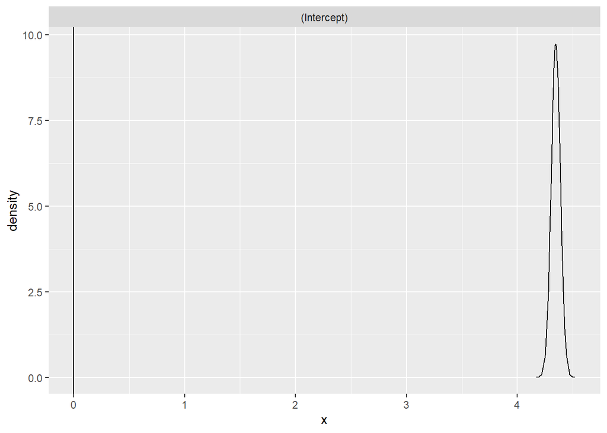

```r
#Plot of each parameters' posterior density
mf <- melt(kgr_model1$marginals.fixed)
cf <- spread(mf,Var2,value)
names(cf)[2] <- 'parameter'
ggplot(cf,aes(x=x,y=y)) + geom_line()+facet_wrap(~ parameter,
           scales="free") + geom_vline(xintercept=0) + ylab("density")
```

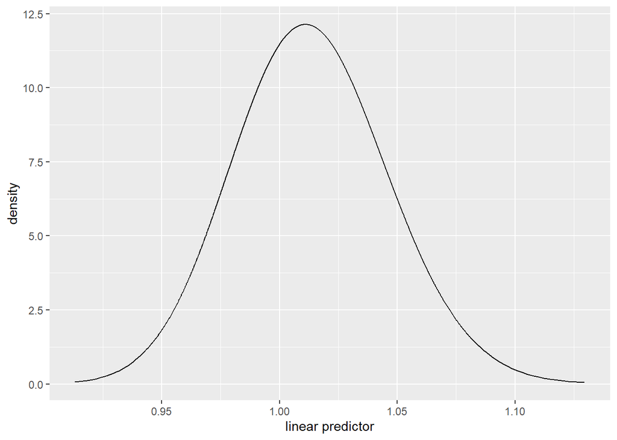

```r
# #Could also use
# bri.fixed.plot(kgr_model1) #option to plot them together = TRUE

# Plot of precision of random effect (main hyperparameter of interest)
sden <- data.frame(bri.hyper.sd(kgr_model1$marginals.hyperpar[[1]]))
    ggplot(sden,aes(x,y)) + geom_line() + ylab("density") +
           xlab("linear predictor")
```

```r
# #Could also use
# bri.hyperpar.plot(kgr_model1)
```

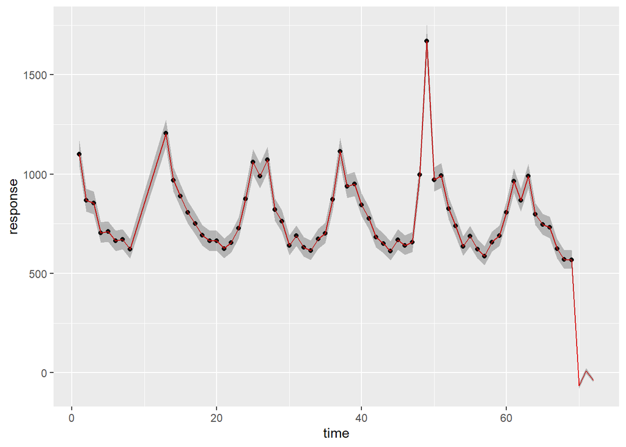

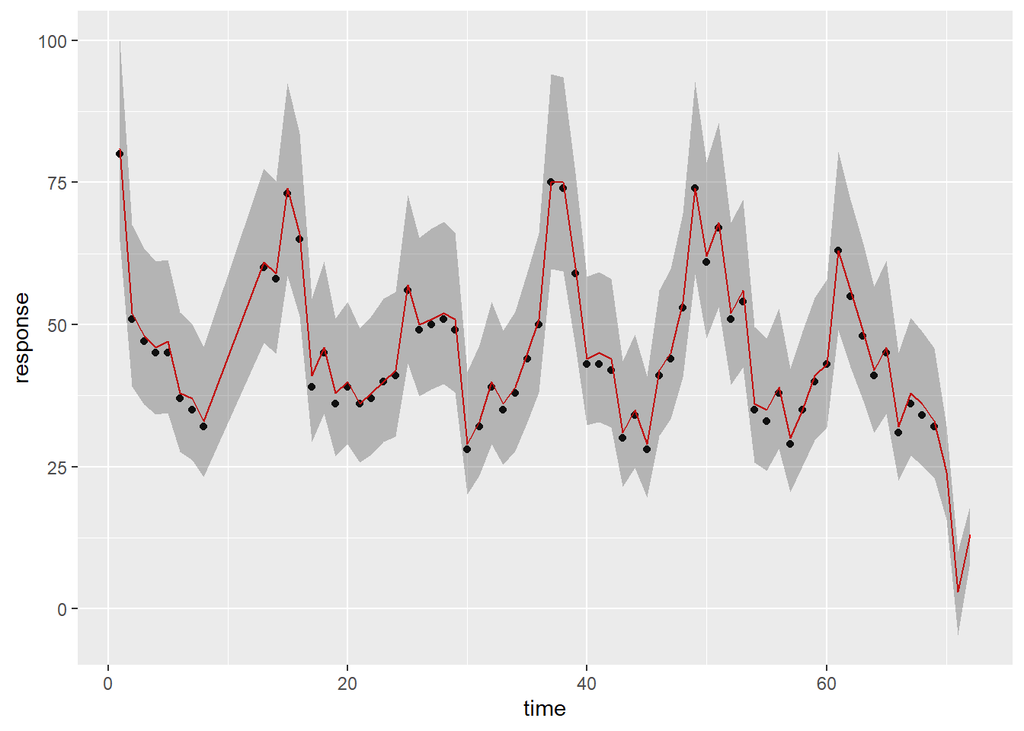

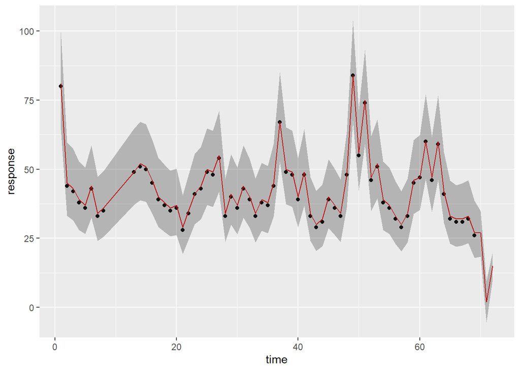

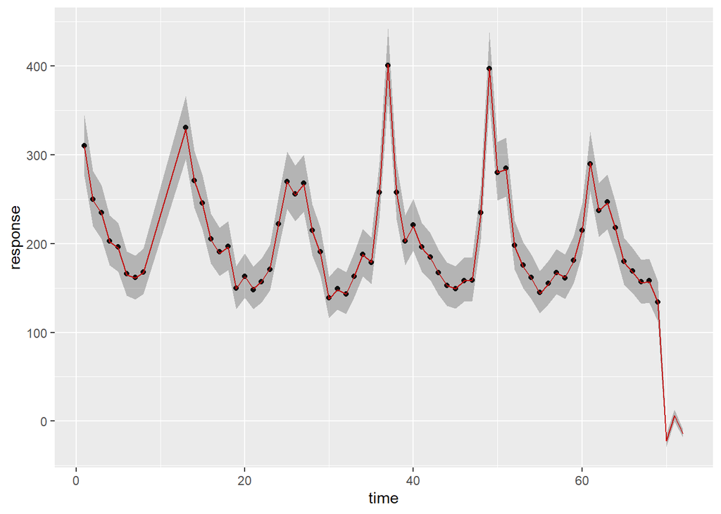

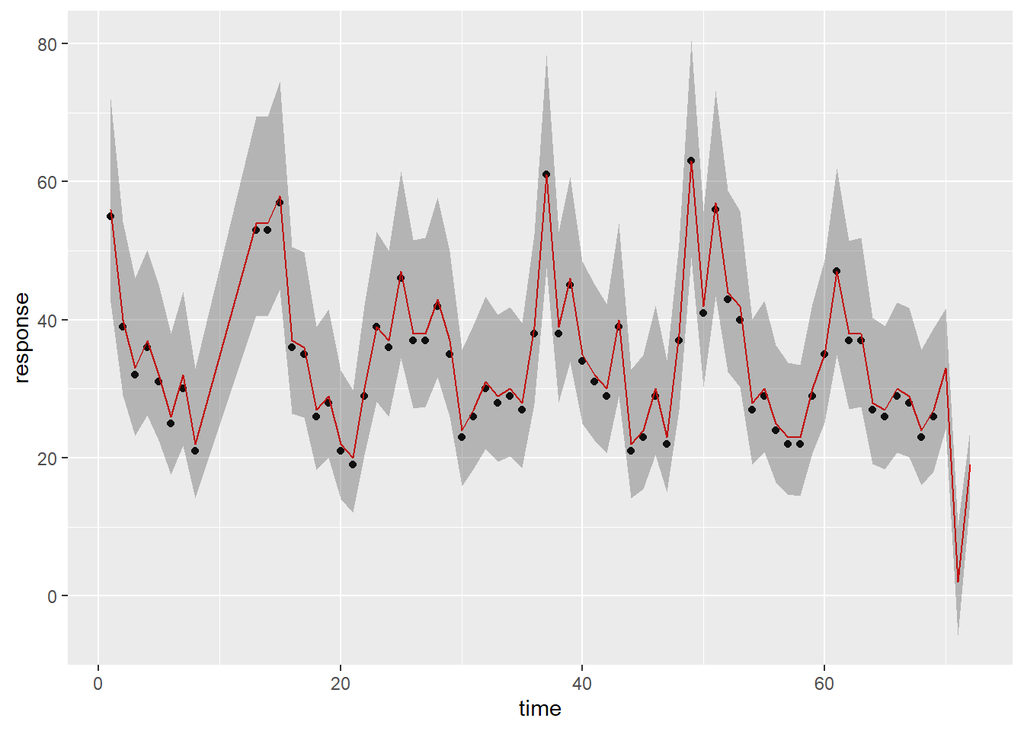

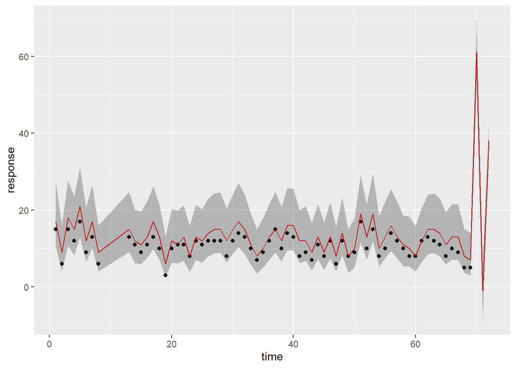

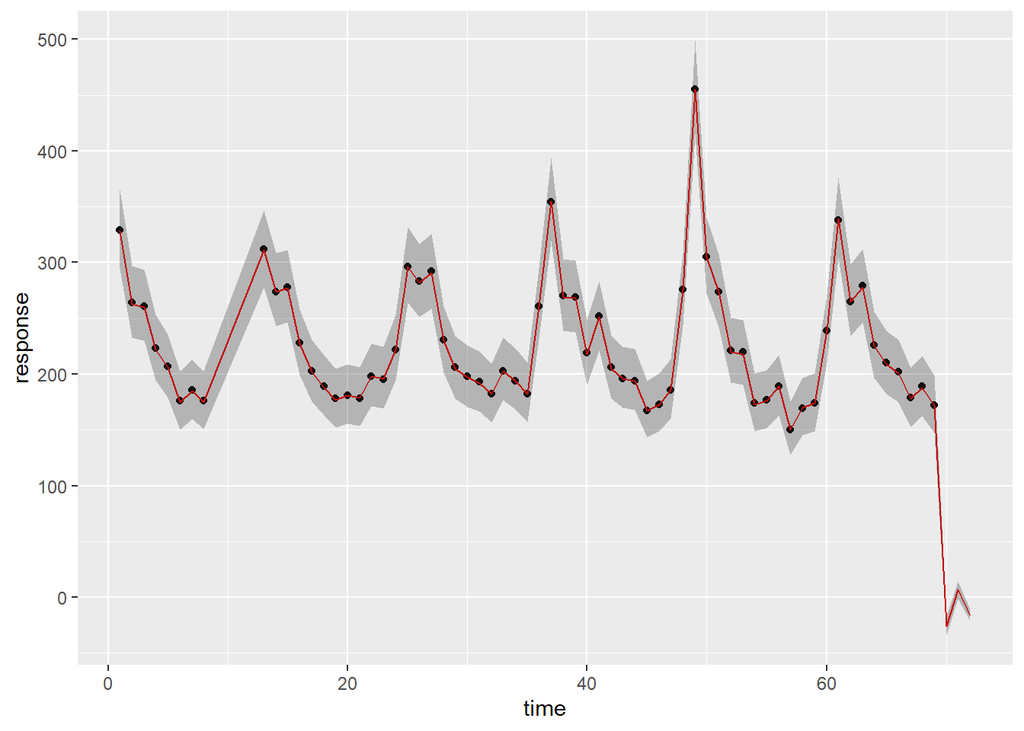

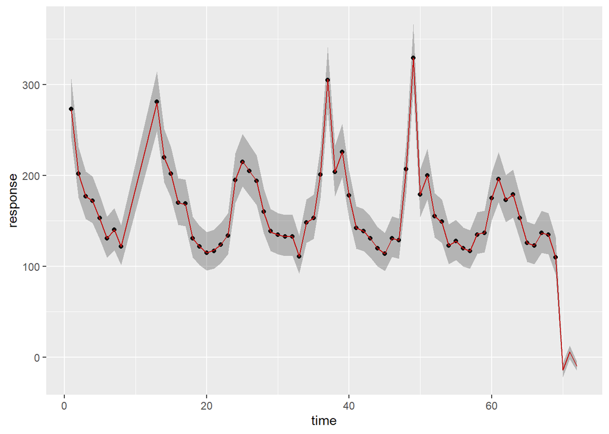

```r
#Plot of posterior predictive estimates with credible interval bands OVERLAID on response

for (i in 1:num_clus){
  df = inla_train_data %>% filter(id == i) %>% select(response)
  preds = preds_kgr_model1 %>% filter(id == i)
  df = cbind(df,preds)

  post_pred_plot = df %>% ggplot(aes(x=time,y=response)) + geom_point() +
    geom_line(aes(y=mean),color = "red") + geom_ribbon(aes(ymin = `0.025quant`,ymax = `0.975quant`),alpha = 0.3)
  print(post_pred_plot)
}
```

```r
# #One call to ggplot (doesn't look as good bc axes aren't clear)
# preds_kgr_model1 %>% ggplot(aes(x=time,y=mean)) + geom_line() + geom_ribbon(aes(ymin = `0.025quant`,ymax = `0.975quant`),alpha = 0.3) + facet_wrap(~ id)

# #Combine plots with library patchwork
# pp_plot_kgr_model1.1 = preds_kgr_model1 %>% filter(id == 1) %>% ggplot(aes(x=time,y=mean)) + geom_line() + geom_ribbon(aes(ymin = `0.025quant`,ymax = `0.975quant`),alpha = 0.3)
#
# pp_plot_kgr_model1.2 = preds_kgr_model1 %>% filter(id == 2) %>% ggplot(aes(x=time,y=mean)) + geom_line() + geom_ribbon(aes(ymin = `0.025quant`,ymax = `0.975quant`),alpha = 0.3)
#
# pp_plot_kgr_model1.3 = preds_kgr_model1 %>% filter(id == 3) %>% ggplot(aes(x=time,y=mean)) + geom_line() + geom_ribbon(aes(ymin = `0.025quant`,ymax = `0.975quant`),alpha = 0.3)
#
# pp_plot_kgr_model1.4 = preds_kgr_model1 %>% filter(id == 4) %>% ggplot(aes(x=time,y=mean)) + geom_line() + geom_ribbon(aes(ymin = `0.025quant`,ymax = `0.975quant`),alpha = 0.3)
#
# pp_plot_kgr_model1.5 = preds_kgr_model1 %>% filter(id == 5) %>% ggplot(aes(x=time,y=mean)) + geom_line() + geom_ribbon(aes(ymin = `0.025quant`,ymax = `0.975quant`),alpha = 0.3)
#
# pp_plot_kgr_model1.6 = preds_kgr_model1 %>% filter(id == 6) %>% ggplot(aes(x=time,y=mean)) + geom_line() + geom_ribbon(aes(ymin = `0.025quant`,ymax = `0.975quant`),alpha = 0.3)
#
# pp_plot_kgr_model1.7 = preds_kgr_model1 %>% filter(id == 7) %>% ggplot(aes(x=time,y=mean)) + geom_line() + geom_ribbon(aes(ymin = `0.025quant`,ymax = `0.975quant`),alpha = 0.3)
#
# pp_plot_kgr_model1.8 = preds_kgr_model1 %>% filter(id == 8) %>% ggplot(aes(x=time,y=mean)) + geom_line() + geom_ribbon(aes(ymin = `0.025quant`,ymax = `0.975quant`),alpha = 0.3)
#
# pp_plot_kgr_model1.1 + pp_plot_kgr_model1.2 + pp_plot_kgr_model1.3 + pp_plot_kgr_model1.4 + pp_plot_kgr_model1.5 + pp_plot_kgr_model1.6 + pp_plot_kgr_model1.7 + pp_plot_kgr_model1.8
```

# Plots of true mortality values

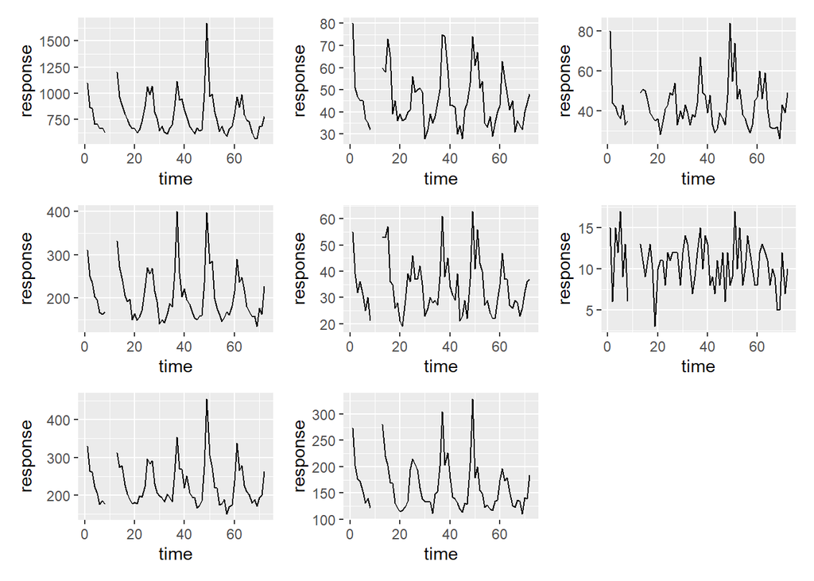

```r
true_mortality = inla_test_data
true_mortality$time = as.numeric(true_mortality$time)

#Combine plots with library patchwork
true1 = true_mortality %>% filter(id == 1) %>% ggplot(aes(x=time,y=response)) + geom_line()

true2 = true_mortality %>% filter(id == 2) %>% ggplot(aes(x=time,y=response)) + geom_line()

true3 = true_mortality %>% filter(id == 3) %>% ggplot(aes(x=time,y=response)) + geom_line()

true4 = true_mortality %>% filter(id == 4) %>% ggplot(aes(x=time,y=response)) + geom_line()

true5 = true_mortality %>% filter(id == 5) %>% ggplot(aes(x=time,y=response)) + geom_line()

true6 = true_mortality %>% filter(id == 6) %>% ggplot(aes(x=time,y=response)) + geom_line()

true7 = true_mortality %>% filter(id == 7) %>% ggplot(aes(x=time,y=response)) + geom_line()

true8 = true_mortality %>% filter(id == 8) %>% ggplot(aes(x=time,y=response)) + geom_line()

true1 + true2 + true3 + true4 + true5 + true6 + true7 + true8
```

# Comparing RMSE for different clusters between models

One way to compare performance between the models fit above is to calculate RMSEs for each model’s fit on each cluster’s time series. Since INLA makes predictions based on the posterior predictive distribution, I actually calculated two sets of RMSEs. The first one is the RMSE of the predictions made by each model on the observed training data points i.e. not months 9-12 or 70-72. These were the observations that the models were fit on so we would expect small discrepancies between the observed values and the posterior predictive means for those time periods. The second one is the RMSE of the predictions made by each model on the test data points i.e. months 70-72. There was a lot more variation in the RMSEs calculated for these data points obviously. Note, we were unable to calculate any RMSE values for months 9-12 because we don’t know what the true values were for those points.

Another important thing to note here is that the RMSEs calculated for each cluster were drastically different because the population sizes between clusters varied by a lot (think thousands compared to hundred thousands). So in order to make actual comparisons, the RMSEs had to be scaled which involves dividing the calculated RMSE by the average of the actual observed data points. The resulting RMSE values for each cluster, which are presented in tables below, can now be interpreted relative to the average number of respiratory related deaths in that cluster.

```r
#Overall fit
num_clus = length(unique(true_mortality$id))
RMSE_table = matrix(nrow=2,ncol=num_clus)
test_RMSE_table = matrix(nrow=2,ncol=num_clus)

for (i in 1:num_clus){
  actual = true_mortality %>% filter(id == i) %>% select(response) %>% data.frame()

  actual.mean = mean(na.omit(actual$response))
  # actual.sd = sd(na.omit(actual$response))

  na_idx = which(is.na(actual$response))
  actual2 = actual[-na_idx,]
  actual2 = actual2[-(66:68)]

  pm_1 = preds_ref_model1 %>% filter(id == i) %>% select(mean,sd) %>% data.frame()
  pm_2 = preds_kgr_model1 %>% filter(id == i) %>% select(mean,sd) %>% data.frame()

  rmse1 = sqrt(mean((actual2 - pm_1$mean[-(66:68)])^2))
  rmse2 = sqrt(mean((actual2 - pm_2$mean[-(66:68)])^2))

  rmse1 = rmse1 / actual.mean
  rmse2 = rmse2 / actual.mean

  RMSE_table[,i] = c(rmse1,rmse2)

  mean(pm_1$sd)
  mean(pm_2$sd)

  actual_test = actual[70:72,]
  pm_1_test = pm_1[66:68,]
  pm_2_test = pm_2[66:68,]

  actual_test_mean = mean(actual_test)

  test_rmse1 = sqrt(mean((actual_test - pm_1_test$mean)^2))
  test_rmse2 = sqrt(mean((actual_test - pm_2_test$mean)^2))

  test_rmse1 = test_rmse1 / actual_test_mean
  test_rmse2 = test_rmse2 / actual_test_mean

  test_RMSE_table[,i] = c(test_rmse1,test_rmse2)
}

#Table 1: RMSE on all points (except missing and test observations)

RMSE_table = data.frame(RMSE_table)
RMSE_table = rbind(RMSE_table,cluster_rmse_gp)

colnames(RMSE_table) = c("Cluster 1","Cluster 2","Cluster 3","Cluster 4",
                         "Cluster 5", "Cluster 6", "Cluster 7", "Cluster 8")
rownames(RMSE_table) = c("Poisson GLM model","KGR model", "GP model")

RMSE_table
```

|  | Cluster 1 | Cluster 2 | Cluster 3 | Cluster 4 | Cluster 5 | Cluster 6 | Cluster 7 | Cluster 8 |
| --- | --- | --- | --- | --- | --- | --- | --- | --- |
| Poisson GLM model | 0.1023731205 | 0.14557368 | 0.15539486 | 0.106199357 | 0.16202042 | 0.2889494 | 0.088923175 | 0.116390768 |
| KGR model | 0.0009028383 | 0.02591262 | 0.02221099 | 0.004653132 | 0.03014676 | 0.2311595 | 0.003631994 | 0.002957283 |
| GP model | 0.1104315927 | 0.12357249 | 0.17346654 | 0.122823398 | 0.15764925 | 0.2760741 | 0.108561017 | 0.133544008 |

```r
#Table 2: RMSE on test dataset

test_RMSE_table = data.frame(test_RMSE_table)

###need to make GP predictions on test cases and attach
test_RMSE_table = rbind(test_RMSE_table,test_rmse_gp)

colnames(test_RMSE_table) = c("Cluster 1","Cluster 2","Cluster 3","Cluster 4",
                         "Cluster 5", "Cluster 6", "Cluster 7", "Cluster 8")
rownames(test_RMSE_table) = c("Poisson GLM model","KGR model", "GP model")

test_RMSE_table
```

|  | Cluster 1 | Cluster 2 | Cluster 3 | Cluster 4 | Cluster 5 | Cluster 6 | Cluster 7 | Cluster 8 |
| --- | --- | --- | --- | --- | --- | --- | --- | --- |
| Poisson GLM model | 0.9927604 | 0.9121162 | 0.9132592 | 0.9846850 | 0.9063645 | 0.8210952 | 0.9853812 | 0.9769352 |
| KGR model | 1.0468913 | 0.7378492 | 0.6972521 | 1.0690954 | 0.6348175 | 3.4043757 | 1.0657647 | 1.0515165 |
| GP model | 0.2758012 | 0.2997933 | 0.4251573 | 0.3750292 | 0.2923049 | 0.2533955 | 0.2825761 | 0.3444974 |

## Sliding timeframe forecasting exercise:

```r
starting_data = inla_test_data[1:288,]
starting_data$months = as.numeric(starting_data$months)
rownames(starting_data) = NULL

while(max(starting_data$time) < 72){

  #Attaches df for next 6 months with NAs in response
  end = nrow(starting_data)
  id = rep(1:8,6)
  id2 = (starting_data$id2[end]+1):(starting_data$id2[end]+48)
  response = rep(NA,48)
  time = rep((starting_data$time[end]+1):(starting_data$time[end]+6),each=8)

  if (starting_data$months[end] == 6){
    months = rep(c(7,8,9,10,11,12),each=8)
  } else if (starting_data$months[end] == 12){
    months = rep(c(1,2,3,4,5,6),each=8)
  }

  new_data = data.frame(id,id2,response,time,months)
  starting_data = rbind(starting_data,new_data)
  starting_data$months = factor(starting_data$months)

  #Fit models on most recent 36 months
  starting_data_subset = starting_data[(nrow(starting_data)-335):nrow(starting_data),]

  #Model 1
  # ref_formula1 = response ~ months + f(id,model = "iid")
  # ref_model1 = inla(ref_formula1,family = "poisson",data = starting_data)
  #
  # preds_ref_model1 = ref_model1$summary.fitted.values
  # preds_ref_model1$mean = round(preds_ref_model1$mean)

  #KGR model
  kgr_formula2 = response ~ f(id,model = "generic0",Cmatrix = covGP[c(starting_data_subset$id2),c(starting_data_subset$id2)])
  #kgr_formula2 = response ~ f(id2,model = "generic0",Cmatrix = covGP[c(starting_data_subset$id2),c(starting_data_subset$id2)])
  kgr_model1 = inla(kgr_formula2, data = starting_data_subset, family = "poisson")

  preds_kgr_model1 = kgr_model1$summary.fitted.values
  preds_kgr_model1$mean = round(preds_kgr_model1$mean)

  #Fill in predicted posterior means to NAs in starting_data
  special_preds = preds_ref_model1$mean[65:96]
  starting_data$response[65:96] = special_preds

  pred_data = preds_ref_model1$mean[(end+1):(end+48)]
  starting_data$response[(end+1):(end+48)] = pred_data

  starting_data$response = replace(starting_data$response,which(starting_data$response < 0),0)
  starting_data$months = as.numeric(starting_data$months)
}
```

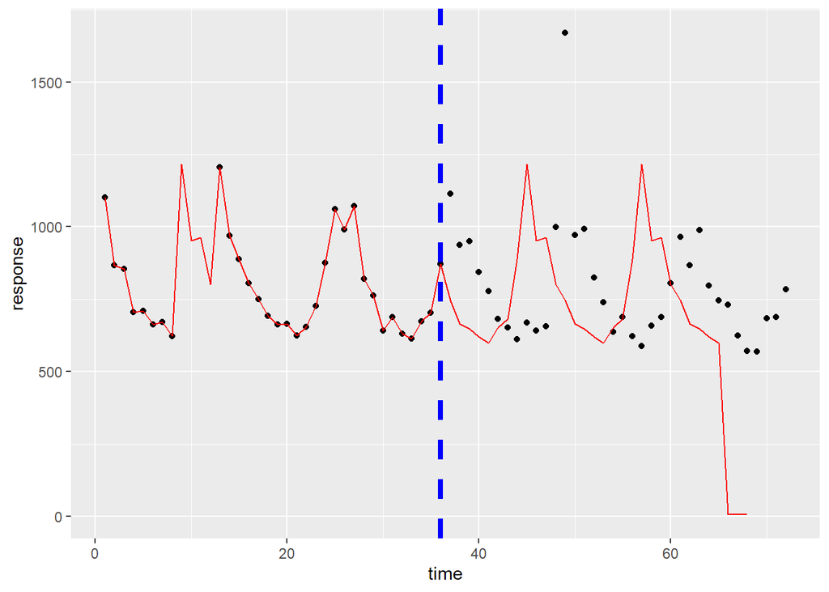

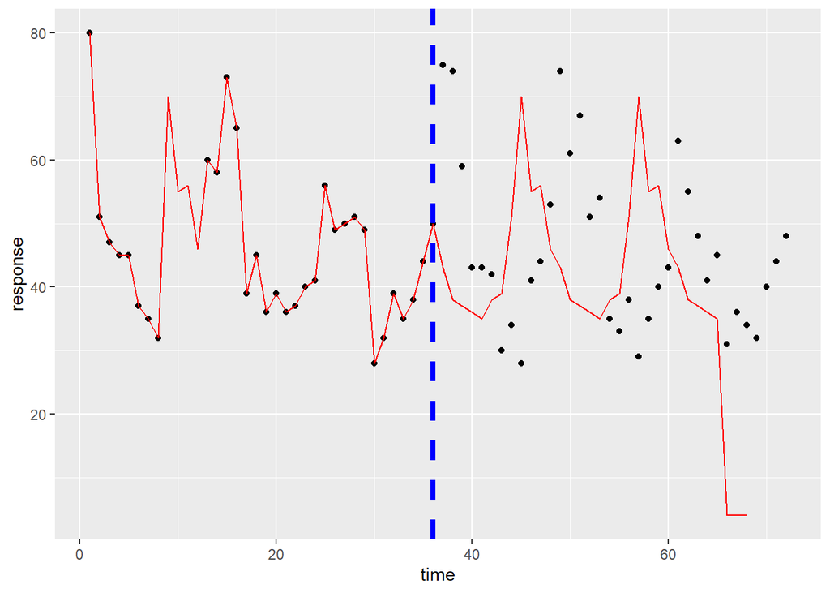

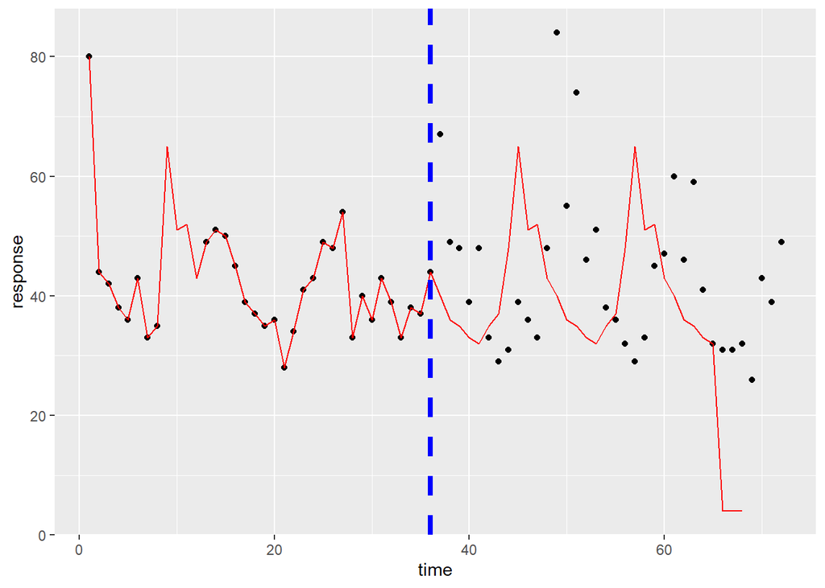

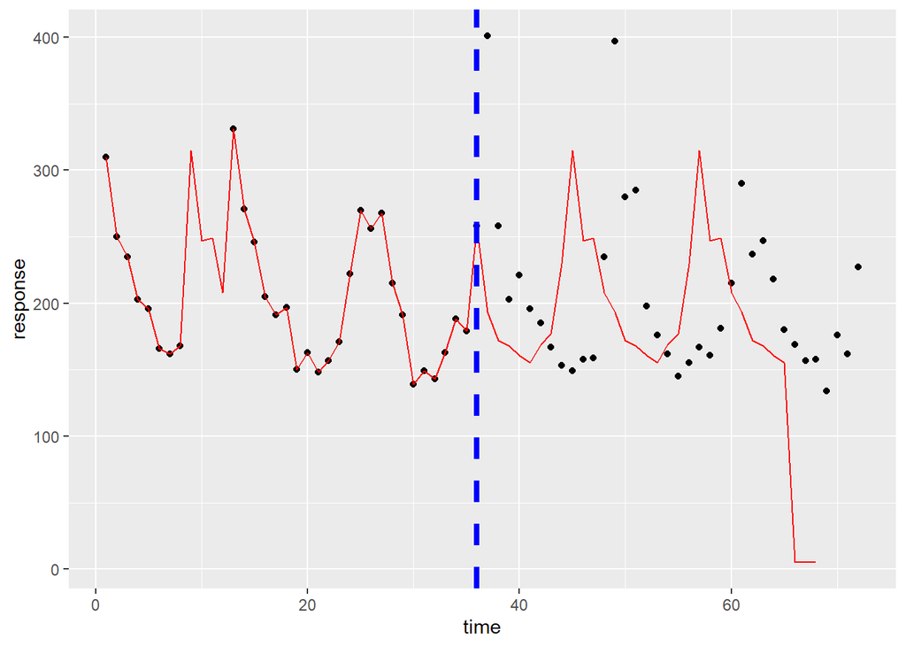

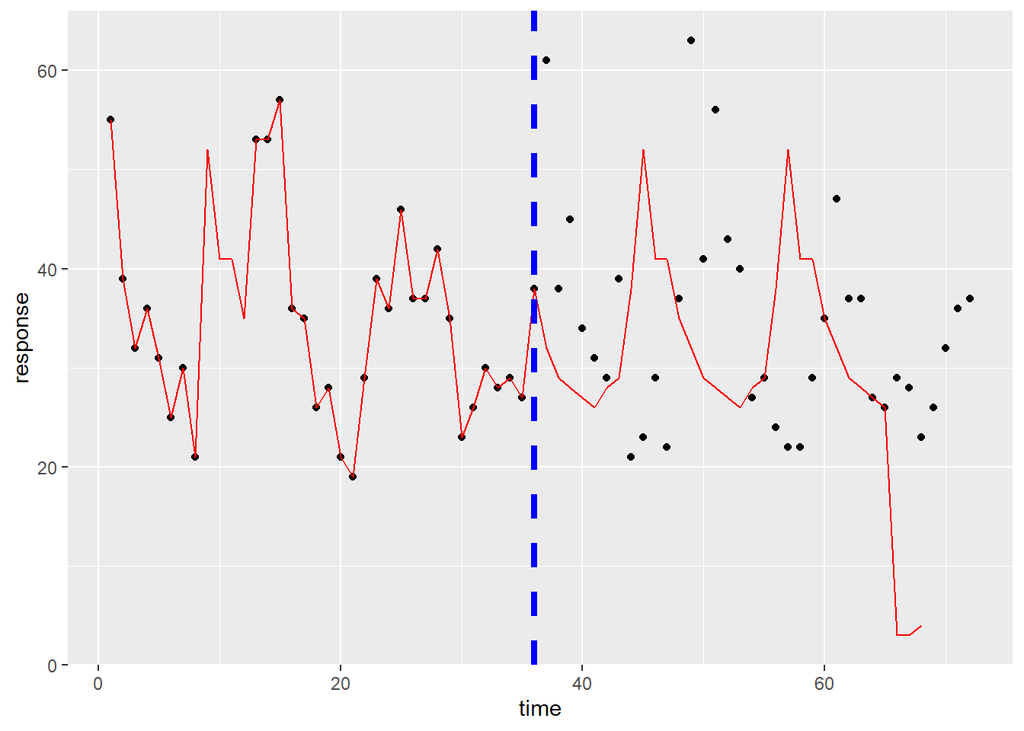

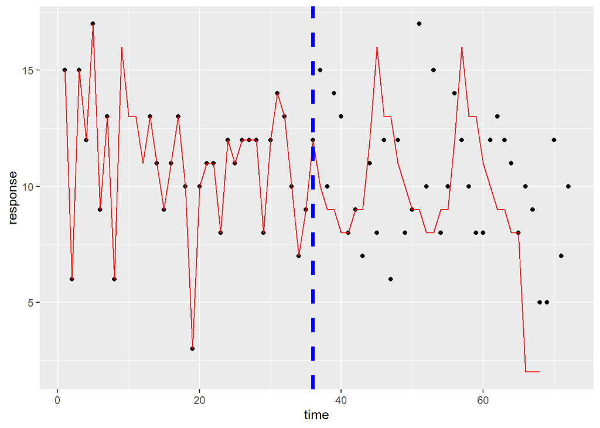

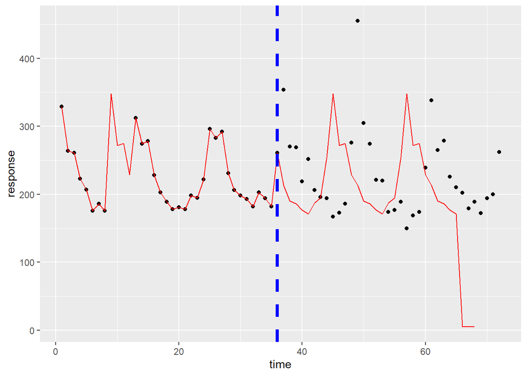

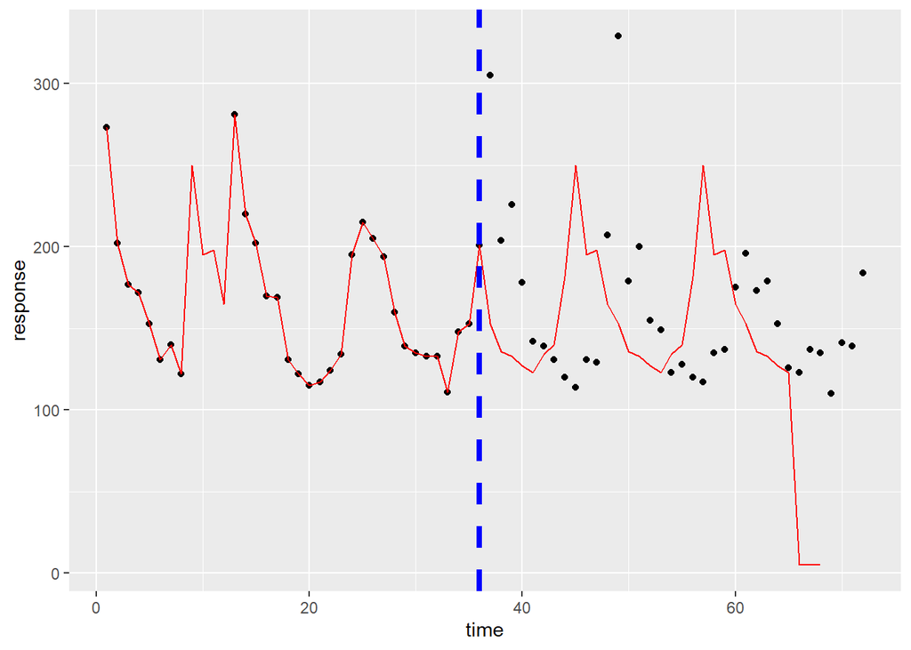

```r
#Plot of posterior predictive estimates (months 37-72) with credible interval bands OVERLAID on response\
for (i in 1:num_clus){
  df = true_mortality %>% filter(id == i) %>% select(response)
  preds = starting_data %>% filter(id == i)
  colnames(preds)[3] = "mean"
  df = cbind(df,preds)

  post_pred_plot = df %>% ggplot(aes(x=time,y=response)) + geom_point() +
    geom_line(aes(y=mean),color = "red") + geom_vline(xintercept = 36,linetype = "dashed",color = "blue",linewidth = 1.5)
  print(post_pred_plot)
}
```